# Project-cheese-Insights

**As we can see the global inflation and the local inflation in Egypt, and also there was a ***problem in importing goods due to the last decisions that were made by Central Bank Egypt*****

I saw a necessary urge to investigate the *dynamic of prices in Cheese* as it is used nearly in every home in Egypt and also with kids in schools.  
I collected data from famous retailer across more than one month and did some insights to get a glimpse of view about cheese market in Egypt lately

> **N.B** *Data was collected from 20-9-2022 to 3-11-2022*

> I will focus on some brands due to its popularity according to the main stream of society and I will neglect the premium ones the brands that i will focus on is
> - La vache qui rit
> - Kiri
> - Domty
> - President

# plotting histogram of prices to see the distribution of prices

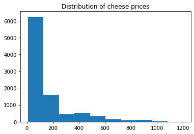

```python
plt.hist(df_tot['RealPrices']);
plt.title('Distribution of cheese prices');
```

**we see that the histogram is right skewed which is expected as we talk about cheese which is supposed that many Products and items has a relative lower price compared to other products , we see that the majority contain prices lower than 200**

## Is the mean of cheese prices is a real indicator for the cheese ?

```python
df_tot['RealPrices'].mean()
```

```
160.50508300062276
```

**the answer is no, as the mean will be affected by the premium products that are there which will push to to be a higher mean a better indicator is to use the median as a measure of average**

```python
df_tot['RealPrices'].median()
```

```
89.95
```

**as expected, the median gives a lower number compared to the mean which was a little deceving measure of average**

## Getting the most date where the max prices happened

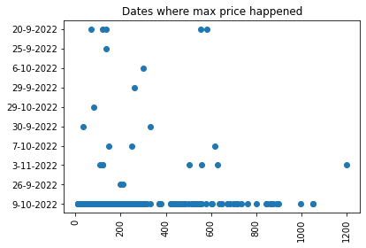

```python
plt.scatter(products_max['RealPrices'],products_max['Date'])
plt.xticks(rotation=90);
plt.title('Dates where max price happened');
```

# **we find that the date where most of the SKUS reached its maximum price was 9-10-2022**

**That is because this date was near two holidays which was sixth october victory and birth of prophet muhammed**

# Analysing every Baramily product

```python
baramily_diff = products_diff[products_diff.index.str.contains(r'Baramily\b')]
baramily_diff =     baramily_diff.sort_values()
baramily_diff
```

```
Products
Domty Natural Baramily Cheese - 500g       3.31
Katilo Baramily Cheese - 1kg               5.00
President Baramily Cheese - 500g          15.51
President Baramily Cheese - 700g          16.41
Alex Baramily Cheese with Pepper - 1kg    21.61
Baramily Cheese - 1kg                     24.00
Name: RealPrices, dtype: float64
```

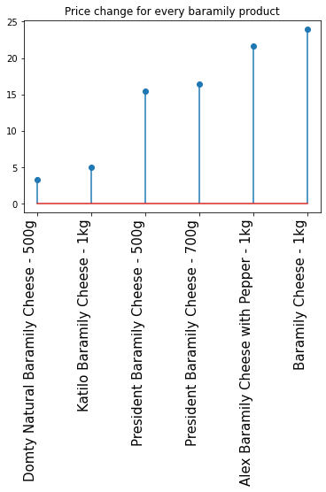

```python
#fig, ax = plt.subplots()
plt.stem(baramily_diff.index,baramily_diff.values)
hh = np.arange(len(baramily_diff.index))

plt.xticks(ticks = hh , rotation=90,fontsize = 9, ha='right');
plt.tick_params(axis='x', which='major', labelsize=15)
plt.title('Price change for every baramily product');
#xtick_loc = [hh]
##ytick_loc = [0.12, 0.80, 0.76]
#plt.set_xticks(xtick_loc)
```

# Analysing every rummy product

```python
rummi_diff = products_diff[products_diff.index.str.contains(r'Rumy\b')]
rummi_diff =     rummi_diff.sort_values()
rummi_diff
```

```
Products
Katilo Rumy Cheese Slices - 200g         2.35
Special Old Rumy Cheese - 1kg           10.00
Katilo Rumy Cheese Slices - 454g        13.51
Rumy Batarekh Extra Cheese Wax - 1kg    25.21
Extra Rumy Batarekh Cheese - 1kg        39.99
Old Rumy Cheese - 1kg                   43.21
Name: RealPrices, dtype: float64
```

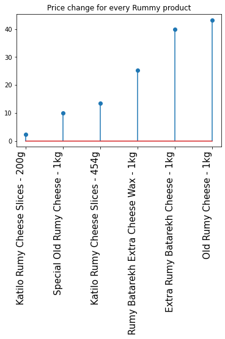

```python
#fig, ax = plt.subplots()
plt.stem(rummi_diff.index,rummi_diff.values)
hh = np.arange(len(rummi_diff.index))

plt.xticks(ticks = hh , rotation=90,fontsize = 9, ha='right');
plt.tick_params(axis='x', which='major', labelsize=15)
plt.title('Price change for every Rummy product');
#xtick_loc = [hh]
##ytick_loc = [0.12, 0.80, 0.76]
#plt.set_xticks(xtick_loc)
```

# Analysing Domty brand

```python
domty_diff = products_diff[products_diff.index.str.match(r'\Domty\b')]
domty_diff=domty_diff.sort_values()
domty_diff
```

```
Products
Domty Feta Plus Che.Yellow T.P.-250g         0.50
Domty Feta Plus Cheese - 250g                0.60
Domty Feta Light Cheese - 250g               0.65
Domty Istanbolly Plus Cheese - 250g          0.65
Domty Feta Plus Olive Cheese - 250g          0.65
Domty Feta Plus Che Yellow Hot T.P- 250g     0.74
Domty Feta Cheese Tetra Pack - 500g          1.05
Domty Istanbolly Cheese - 500g               1.05
Domty Feta Plus Che Yellow Hot T.P- 500g     1.49
Domty Feta Cheese with Olives - 250g         1.85
Domty Istanbolly Cheese - 250g               1.85
Domty Feta Cheese - 250g                     1.85
Domty Feta Cheese T.Pack Natural 500G        2.40
Domty White Low Salt Cheese - 400g           2.49
Domty Natural Istanbolly Cheese - 500g       2.51
Domty Olive Cheese Spread - 220g             2.55
Domty Paprika Cheese Spread - 220g           2.55
Domty Plain Cheese Spread - 220g             2.55
Domty Romy Cheese Spread - 220g              2.55
Domty Cheddar Cheese Spread - 220g           2.55
Domty Light Cheese Spread - 220g             2.55
Domty Feta Plus Olive Cheese - 500g          2.61
Domty Istanbolly Plus Cheese - 500g          2.61
Domty Feta Plus Che.Yellow T.P.- 500g        2.61
Domty Feta Plus Light Cheese T-Pack 500g     2.61
Domty Light Natural Cheese - 500g            2.76
Domty Natural Baramily Cheese - 500g         3.31
Domty Natural Feta Cheese - 500g             3.50
Domty Feta Plus Cheese - 500g                5.10
Domty Feta Plus Cheese - 1kg                 6.35
Domty Istanbolly Cheese - 1kg                6.35
Domty Low Salt Feta Cheese - 1kg             6.35
Domty Shredded Mozzarella Cheese - 200g      7.25
Domty Shredded Mozzarella Cheese - 300g      7.51
Domty Choco Spread - 220g                    9.15
Domty Shredded Mozzarella Plus - 300g        9.35
Domty Mozzarella Cheese Mix - 300g           9.35
Domty Mozzarella Cheese - 500g              13.45
Domty Spread Choco - 380g                   14.04
Domty Paprika Cheese Spread - 380g          17.26
Domty Cheese Spread with Olives - 380g      17.61
Domty Cheddar Cheese Spread - 380g          17.61
Domty Romy Cheese Spread - 380g             17.61
Domty Light Cheese Spread - 380g            17.61
Domty Plain Cheese Spread - 380g            20.31
Domty Salted White Cheese - 900g            22.11
Domty Mozzarella Gold Shreded - 300G        22.91
Domty White Low Salt Cheese - 1kg           30.15
Domty Shredded Mozzarella - 575g            32.31
Domty Mozzarella - 1Kg                      43.75
Domty Feta Cheese with Olives - 500g        49.35
Name: RealPrices, dtype: float64
```

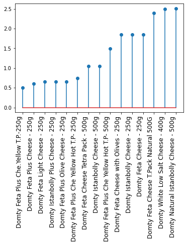

```python
#fig, ax = plt.subplots()
plt.stem(domty_diff.index[0:15],domty_diff.values[0:15])
hh = np.arange(len(domty_diff.index[0:15]))

plt.xticks(ticks = hh , rotation=90,fontsize = 10, ha='right');
plt.tick_params(axis='x', which='major', labelsize=12)

#xtick_loc = [hh]
##ytick_loc = [0.12, 0.80, 0.76]
#plt.set_xticks(xtick_loc)
```

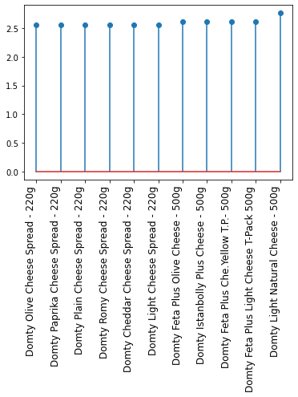

```python
#fig, ax = plt.subplots()
plt.stem(domty_diff.index[15:26],domty_diff.values[15:26])
hh = np.arange(len(domty_diff.index[15:26]))

plt.xticks(ticks = hh , rotation=90,fontsize = 10, ha='right');
plt.tick_params(axis='x', which='major', labelsize=12)

#xtick_loc = [hh]
##ytick_loc = [0.12, 0.80, 0.76]
#plt.set_xticks(xtick_loc)
```

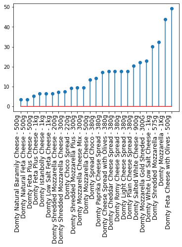

```python
#fig, ax = plt.subplots()
plt.stem(domty_diff.index[26:],domty_diff.values[26:])
hh = np.arange(len(domty_diff.index[26:]))

plt.xticks(ticks = hh , rotation=90,fontsize = 10, ha='right');
plt.tick_params(axis='x', which='major', labelsize=12)

#xtick_loc = [hh]
##ytick_loc = [0.12, 0.80, 0.76]
#plt.set_xticks(xtick_loc)
```

## Analysing of Kiri brand

```python
kiri_diff = products_diff[products_diff.index.str.match(r'Kiri\b')]
kiri_diff = kiri_diff.sort_values()
kiri_diff
```

```
Products
Kiri Squared Cheese - 6 Pieces              1.51
Kiri Cream Spread Cheese - 8 Pieces         1.90
Kiri Greek - 200g                           2.31
Kiri Cream Spread Cheese - 200g             2.35
Kiri Cream Labneh - 350g                    3.81
Kiri Creamy Spread - 350g                   3.81
Kiri Greek -350g                            3.81
Kiri Cream Labneh - 500g                    5.01
Kiri Cream Spread Cheese - 500g             5.01
Kiri Cream Labneh - 200g                    6.81
Kiri Cream Spread Cheese - 12 Pieces        9.31
Kiri Squared Cheese - 48 Pieces             9.50
Kiri with Basturma - 1kg                   10.01
Kiri Labneh Cheese - 1kg                   10.01
Kiri Squared Cheese - 24 Pieces + Boxes    12.51
Kiri Labneh with Rummy - 1kg               15.01
Kiri Cheese - 1kg                          17.00
Kiri Labneh with Edam - 1kg                21.00
Kiri Hot - 1kg                             21.00
Kiri Squared Cheese - 24 Pieces            21.31
Name: RealPrices, dtype: float64
```

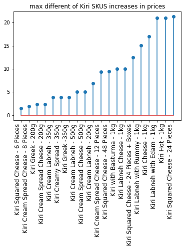

```python
#fig, ax = plt.subplots()
plt.stem(kiri_diff.index,kiri_diff.values)
hh = np.arange(len(kiri_diff.index))

plt.xticks(ticks = hh , rotation=90,fontsize = 12, ha='right');
plt.tick_params(axis='x', which='major', labelsize=12)
plt.title('max different of Kiri SKUS increases in prices');
#xtick_loc = [hh]
##ytick_loc = [0.12, 0.80, 0.76]
#plt.set_xticks(xtick_loc)
```

# analysing of La vache qui rit brand

```python
lvqr_diff = products_diff[products_diff.index.str.match(r'La Vache\b')]
lvqr_diff
```

```
Products
La Vache Cheese - 8 Piece                   2.24
La Vache Cheese Orange - 32 Piece          17.00
La Vache Cream Cheese - 350g                3.21
La Vache Pick & Crock - 35g                 1.24
La Vache Pick & Crock 4Tubs - 140g          1.60
La Vache Qui Rit Cheddar Cheese - 200g      1.50
La Vache Qui Rit Cheddar Cheese - 350g      3.21
La Vache Qui Rit Cheese - 16 Pieces         9.51
La Vache Qui Rit Cheese - 8 Pieces          3.00
La Vache Qui Rit Cream Cheese - 200g        1.50
La Vache Qui Rit Double Cheese - 32 Pcs     5.25
La Vache Qui Rit Tri.Cheese - 24 Pieces     5.00
La Vache Qui Rit Tri.Cheese - 48 Pieces    11.00
Name: RealPrices, dtype: float64
```

```python
lvqr_diff= lvqr_diff.sort_values()
```

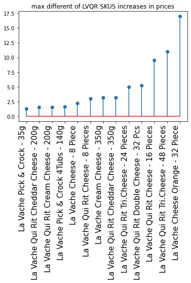

```python
#fig, ax = plt.subplots()
plt.stem(lvqr_diff.index,lvqr_diff.values)
hh = np.arange(len(products_diff[products_diff.index.str.match(r'La Vache\b')].index))

plt.xticks(ticks = hh , rotation=90,fontsize = 14, ha='right');
plt.tick_params(axis='x', which='major', labelsize=15)
plt.title('max different of LVQR SKUS increases in prices');
#xtick_loc = [hh]
##ytick_loc = [0.12, 0.80, 0.76]
#plt.set_xticks(xtick_loc)
```